# Michaelis-Menten Model

Hao-Ran Wu ( haoranwu @ zju.edu.cn )

2022-09-15

In this section we are concerned about how to calculate ecosystem production based on Michaelis-Menten (MM) model.

## Code Example(s)

```r
# Ecosystem Production based on Michaelis-Menten (MM) Model
# *****************************************************************
#
# Calculate ecosystem production based on Michaelis-Menten (MM) Model (Michaelis
# and Menten, 1913)
#
# ********************************
# List of variables and units for this example
#
# 'PAR'           photosynthetically active radiation (μmol m-2 s-1)
# 'alpha'         photochemical efficiency of photosynthesis at low light
# 'Pm'            maximum photosynthetic capacity (μmol m-2 s-1)
# 'Rd'            respiration rate (μmol m-2 s-1)
# 'beta'          additional shape factor
#
# Calculated variables in the program
# 'Pn_MM'         photosynthesis rate (μmol m-2 s-1) given by MM model
# 'Pn_landsand'   photosynthesis rate (μmol m-2 s-1) given by Landsand model
#
# ********************************
# Step 1: import package
require(bproce)

# Step 2: choose parameters
PAR   <- seq(0, 1000, 10)
alpha <- 0.05
Pm    <- 10
Rd    <- 0
beta  <- -2       # must be less than 1

# Step 3: run the model
Pn_MM <- photo.michment(PAR, alpha = alpha, Pm = Pm, Rd = Rd)
Pn_landsand <- photo.michment(PAR, method = "landsand",
                              alpha = alpha, Pm = Pm, Rd = Rd, beta = -2)

# Step 4: present and visualize the result
print(data.frame(PAR = PAR, Pn_MM = Pn_MM, Pn_landsand = Pn_landsand), digits = 3)

plot(
  PAR, Pn_MM, col=2, ylim=range(c(Pn_MM, Pn_landsand)), type="l",
  xlab = "Photosynthetically active radiation",
  ylab = "Photosynthesis rate",
  main = "Photosynthesis Rate Estimated by MM and Landsand Model"
)                       # plot photosynthesis rate versus PAR (MM model)
lines(PAR, Pn_landsand, col=3, type="l")
                        # plot photosynthesis rate versus PAR (Landsand model)
legend("right", pch=c(15, 15), col=c(2, 3), bty="n",
       legend=c("MM Model", "Landsand Model")) # add legends
```

## Explanation

**Step1:** Load the package `bproce` through the `require()` function.

```r
require(bproce)
```

**Step2:** Choose model parameters.

- `PAR`: Photosynthetically active radiation ($PAR$, µmol m<sup>−2</sup> s<sup>−1</sup>). The provided example calculates photosynthesis rate ($P_n$, µmol m<sup>−2</sup> s<sup>−1</sup>) when $PAR$ changes from 0 to 1000 µmol m<sup>−2</sup> s<sup>−1</sup>.
- `alpha`: Photochemical efficiency of photosynthesis at low light. A model parameter used in both equation (1) and (2). The provided example uses 0.05.
- `Pm`: Maximum photosynthetic capacity (µmol m<sup>−2</sup> s<sup>−1</sup>). A model parameter used in both equation (1) and (2). The provided example uses 10 µmol m<sup>−2</sup> s<sup>−1</sup>.
- `Rd`: Respiration rate (µmol m<sup>−2</sup> s<sup>−1</sup>). A model parameter used in both equation (1) and (2). The provided example assumes no respiration.
- `beta`: Additional shape factor. A model parameter only used in equation (2). It should be less than 1.

```r
PAR   <- seq(0, 1000, 10)
alpha <- 0.05
Pm    <- 10
Rd    <- 0
beta  <- -2
```

**Step3:** Run the model. The relationship between $P_n$ and $PAR$, also commonly known as light response curve, is expressed as a rectangular hyperbolic model:

$$P_n=\frac{\alpha·PAR·P_m}{\alpha·PAR+P_m}-R_d,\quad (1)$$

where $\alpha$ is the photochemical efficiency of photosynthesis at low light, $P_m$ (µmol m<sup>−2</sup> s<sup>−1</sup>) is the maximum photosynthetic capacity of a leaf or an ecosystem, $R_d$ is the respiration rate (µmol m<sup>−2</sup> s<sup>−1</sup>).

```r
Pn_MM <- photo.michment(PAR, alpha = alpha, Pm = Pm, Rd = Rd)

print(head(data.frame(PAR = PAR, Pn_MM = Pn_MM)), digits = 3)
```

```
  PAR Pn_MM
1   0 0.000
2  10 0.476
3  20 0.909
4  30 1.304
5  40 1.667
6  50 2.000
```

Landsberg and Sands (2011) introduced an additional shape factor ($\beta$) into a non-rectangular hyperbolic model:

$$P_n=P_m·\frac{2·\alpha·PAR/P_m}{1+\alpha·\frac{PAR}{P_m}+\sqrt{(1+\alpha·\frac{PAR}{P_m})^2-4·\alpha·\beta·PAR/P_m}},\quad
(2)$$
This model is virtually the same as equation (1) when $β = 0$. The value of $β$ should be less than 1 for simulations. The following example shows how to calculate *P<sub>n</sub>* using eq. 2:

```r
Pn_landsand <- photo.michment(PAR, method = "landsand",
                              alpha = alpha, Pm = Pm, Rd = Rd, beta = beta)

print(head(data.frame(PAR = PAR, Pn_landsand = Pn_landsand)), digits = 3)
```

```
  PAR Pn_landsand
1   0       0.000
2  10       0.439
3  20       0.794
4  30       1.096
5  40       1.359
6  50       1.594
```

An alternative expression of the non-rectangular hyperbolic model is:

$$P_n=\frac{1}{2·\beta}[\alpha·PAR+P_m-\sqrt{(\alpha·PAR+P_m)^2-4·\alpha·PAR·P_m·\beta}],\quad
(3)$$
Equation (3) gives almost the same estimates as equation (2).

```r
Pn_peat <- photo.michment(PAR, method = "peat",
                          alpha = alpha, Pm = Pm, Rd = Rd, beta = beta)

print(head(data.frame(PAR = PAR,
                      Pn_landsand = Pn_landsand,
                      Pn_peat = Pn_peat)), digits = 3)
```

```
  PAR Pn_landsand Pn_peat
1   0       0.000   0.000
2  10       0.439   0.439
3  20       0.794   0.794
4  30       1.096   1.096
5  40       1.359   1.359
6  50       1.594   1.594
```

**Step4:** Present and visualize results. Combine the results by columns and view them through the function `data.frame`:

```r
print(
  head(data.frame(PAR = PAR, Pn_MM = Pn_MM, Pn_landsand = Pn_landsand)),
  digits = 3
)
```

```
  PAR Pn_MM Pn_landsand
1   0 0.000       0.000
2  10 0.476       0.439
3  20 0.909       0.794
4  30 1.304       1.096
5  40 1.667       1.359
6  50 2.000       1.594
```

Create a line plot of calculated variables against $PAR$ through the function `plot()`:

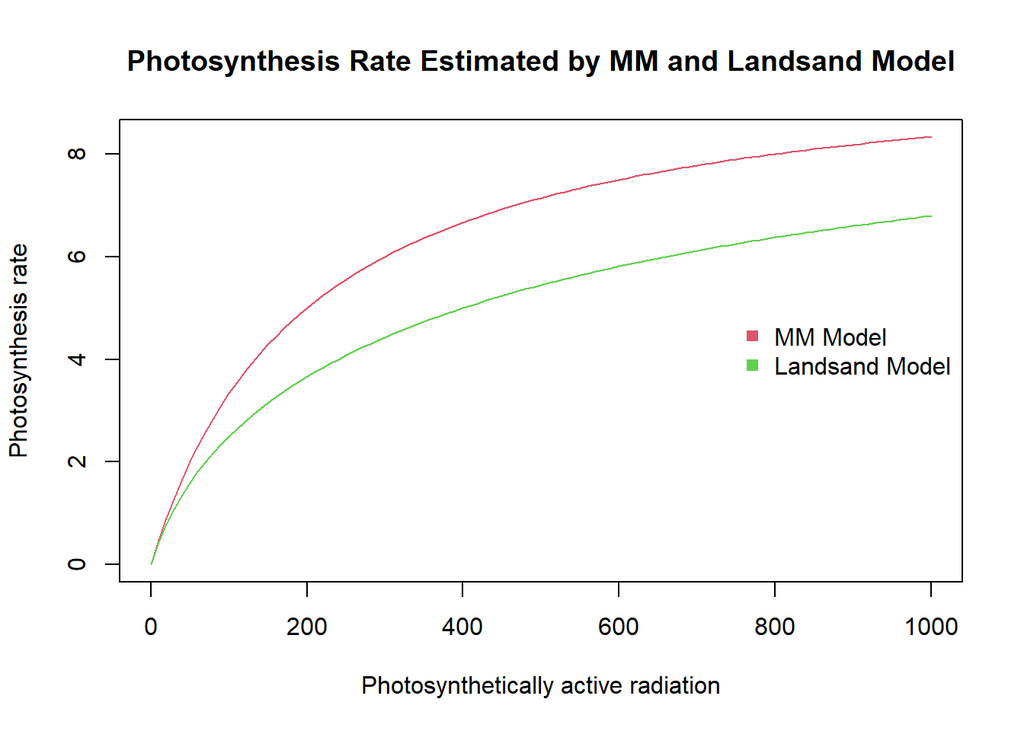

```r
plot(
  PAR, Pn_MM, col=2, ylim=range(c(Pn_MM, Pn_landsand)), type="l",
  xlab = "Photosynthetically active radiation",
  ylab = "Photosynthesis rate",
  main = "Photosynthesis Rate Estimated by MM and Landsand Model"
)                       # plot photosynthesis rate versus PAR (MM model)
lines(PAR, Pn_landsand, col=3, type="l")
                        # plot photosynthesis rate versus PAR (Landsand model)
legend("right", pch=c(15, 15), col=c(2, 3), bty="n",
       legend=c("MM Model", "Landsand Model")) # add legends
```